# **Predicting Blood Pressure Based on Key Cardiovascular Attributes**

**Group Name:** Group 3

**Name(s) & ID(s) of Group Members:**

- Adem Truong (s3900998)
- Carter Facey-Smith (s3907874)
- Max Foord (s3888349)
- Introduction
  - Dataset Source
  - Dataset Details
  - Dataset Features
  - Target Feature
- Goals and Objectives
- Data Cleaning and Preprocessing
- Data Exploration and Visualisation
- Summary and Conclusion
- References

# **Introduction**

#### **Dataset Source**

The Heart Failure Prediction dataset used in this study was sourced from Kaggle (fedesoriano, 2021). This dataset contains health marker information for key precursors to cardiovascular disease based, and was amalgamated from the following datasets by the author:

1. Hungarian Institute of Cardiology. Budapest: Andras Janosi, M.D.
2. University Hospital, Zurich, Switzerland: William Steinbrunn, M.D.
3. University Hospital, Basel, Switzerland: Matthias Pfisterer, M.D.
4. V.A. Medical Center, Long Beach and Cleveland Clinic Foundation: Robert Detrano, M.D., Ph.D.

#### **Dataset Features**

The features in our dataset are described in the table below. These descriptions are taken from the Kaggle attribute information directly.

```python
from tabulate import tabulate

table = [['Name', 'Data Type', 'Units', 'Description'],
         ['Age', 'Numeric', 'NA', 'Age of the patient in years'],
         ['Sex', 'Nominal Categorical', 'NA', 'Sex of the patient [M: Male, F: Female'],
         ['ChestPainType', 'Nominal Categorical', 'NA', 'Chest pain type [TA: Typical Angina, ATA: Atypical Angina, NAP: Non-Anginal Pain, ASY: Asymptomatic]'],
         ['RestingBP', 'Numeric', 'mm HG', 'Resting blood pressure'],
         ['Cholesterol', 'Numeric', 'mm/dl', 'Serum cholesterol'],
         ['FastingBS', 'Binary', 'NA', 'Fasting blood sugar [1: if FastingBS > 120 mg/dl, 0: otherwise]'],
         ['RestingECG', 'Nominal Categorical', 'NA', 'Normal: Normal, ST: having ST-T wave abnormality (T wave inversions and/or ST elevation or depression of > 0.05 mV), LVH: showing probable or definite left ventricular hypertrophy by Estes criteria]'],
         ['MAXHR', 'Numeric', 'NA', 'Maximum heart rate achieved [Numeric value between 60 and 202]'],
         ['ExerciseAngina', 'Binary', 'NA', 'Exercise-induced angina [Y: Yes, N: No]'],
         ['OldPeak', 'Numeric', 'NA', 'Oldpeak = ST [Numeric value measured in depression]'],
         ['ST_Slope', 'Nominal Categorical', 'NA', 'The slope of the peak exercise ST segment [Up: upsloping, Flat: flat, Down: downsloping]'],
         ['HeartDisease', 'Binary', 'NA', 'Output class [1: heart disease, 0: Normal]']]

print(tabulate(table, headers='firstrow', tablefmt='simple'))
```

```
Name            Data Type            Units    Description
--------------  -------------------  -------  ------------------------------------------------------------------------------------------------------------------------------------------------------------------------------------------------------
Age             Numeric              NA       Age of the patient in years
Sex             Nominal Categorical  NA       Sex of the patient [M: Male, F: Female
ChestPainType   Nominal Categorical  NA       Chest pain type [TA: Typical Angina, ATA: Atypical Angina, NAP: Non-Anginal Pain, ASY: Asymptomatic]
RestingBP       Numeric              mm HG    Resting blood pressure
Cholesterol     Numeric              mm/dl    Serum cholesterol
FastingBS       Binary               NA       Fasting blood sugar [1: if FastingBS > 120 mg/dl, 0: otherwise]
RestingECG      Nominal Categorical  NA       Normal: Normal, ST: having ST-T wave abnormality (T wave inversions and/or ST elevation or depression of > 0.05 mV), LVH: showing probable or definite left ventricular hypertrophy by Estes criteria]
MAXHR           Numeric              NA       Maximum heart rate achieved [Numeric value between 60 and 202]
ExerciseAngina  Binary               NA       Exercise-induced angina [Y: Yes, N: No]
OldPeak         Numeric              NA       Oldpeak = ST [Numeric value measured in depression]
ST_Slope        Nominal Categorical  NA       The slope of the peak exercise ST segment [Up: upsloping, Flat: flat, Down: downsloping]
HeartDisease    Binary               NA       Output class [1: heart disease, 0: Normal]
```

# **Goals and Objectives**

High blood pressure is an extremely prevalent, that effects a large portion of the global population. Early detection of the condition is especially important, as high blood pressure is a highly treatable condition, however, if untreated can lead to harmful diseases. A model that could aid in prediction of this condition would assist health workers in 'catching' the condition before it progresses, allowing for early treatment options.

Thus, the main objective of this project is as follows: (1) investigate whether key health markers correlate to an increase of blood pressure (2) if they are found to do so then we will ascertain which markers possess the greatest effect. Naturally this is alongside the general exploratory data analysis, cleaning and preprocessing as tasked by this Phase 1 report.

Prior to commencing, we make the assumption that the rows in our dataset are not correlated, ie that the individuals studied in the various reports that make up this dataset have no bearing on the data of each other. Whilst we believe this assumption to be a realistic one for the subject matter in question, we are not privy to the details of the participants and as such cannot know with certainty.

# **Data Cleaning and Preprocessing**

In this section, we describe the data cleaning and preprocessing steps undertaken for this project.

#### **Data Retrieval**

```python
# Import and setup
import warnings
warnings.filterwarnings("ignore")

import numpy as np
import pandas as pd
import io
import requests

pd.set_option('display.max_columns', None)

import matplotlib.pyplot as plt
import seaborn as sns
%matplotlib inline
%config InlineBackend.figure_format = 'retina'
plt.style.use("ggplot")

# Import the dataset and display 15 rows randomly
heart_df = pd.read_csv(io.BytesIO(uploaded['heart.csv']))
heart_df.sample(15, random_state=101)
```

|  | Age | Sex | ChestPainType | RestingBP | Cholesterol | FastingBS | RestingECG | MaxHR | ExerciseAngina | Oldpeak | ST_Slope | HeartDisease |
| --- | --- | --- | --- | --- | --- | --- | --- | --- | --- | --- | --- | --- |
| 417 | 44 | M | ASY | 130 | 209 | 0 | ST | 127 | N | 0.0 | Up | 0 |
| 325 | 42 | M | ASY | 105 | 0 | 1 | Normal | 128 | Y | -1.5 | Down | 1 |
| 267 | 34 | M | ATA | 98 | 220 | 0 | Normal | 150 | N | 0.0 | Up | 0 |
| 241 | 54 | M | ASY | 200 | 198 | 0 | Normal | 142 | Y | 2.0 | Flat | 1 |
| 367 | 68 | M | ASY | 135 | 0 | 0 | ST | 120 | Y | 0.0 | Up | 1 |
| 352 | 56 | M | ASY | 120 | 0 | 0 | ST | 100 | Y | -1.0 | Down | 1 |
| 171 | 40 | M | NAP | 140 | 235 | 0 | Normal | 188 | N | 0.0 | Up | 0 |
| 218 | 55 | M | ATA | 140 | 196 | 0 | Normal | 150 | N | 0.0 | Up | 0 |
| 624 | 63 | F | ASY | 150 | 407 | 0 | LVH | 154 | N | 4.0 | Flat | 1 |
| 514 | 43 | M | ASY | 122 | 0 | 0 | Normal | 120 | N | 0.5 | Up | 1 |
| 435 | 60 | M | ASY | 152 | 0 | 0 | ST | 118 | Y | 0.0 | Up | 0 |
| 532 | 55 | M | ASY | 116 | 186 | 1 | ST | 102 | N | 0.0 | Flat | 1 |
| 179 | 46 | F | ASY | 130 | 238 | 0 | Normal | 90 | N | 0.0 | Up | 0 |
| 391 | 70 | M | ASY | 115 | 0 | 0 | ST | 92 | Y | 0.0 | Flat | 1 |
| 100 | 65 | M | ASY | 130 | 275 | 0 | ST | 115 | Y | 1.0 | Flat | 1 |

#### **Data Cleaning**

- Changing of any UIDS
- Removal of constant features
- Removal of irrelevant and redundant features
- As there are no datetime features these do not need to be removed
- Dealing with outliers via either clamping, imputing or dropping of values
- Removal of missing rows with missing values
- Encoding of necessary features
- Any necessary scaling of now converted descriptive features

As our dataset is quite clean already, minimal cleanup needed to be performed, barring the below. As requested we have left the task of clamping, scaling, outlier handling, and encoding for Phase 2.

We will begin by displaying all columns in our dataset.

```python
heart_df.columns
```

```
Index(['Age', 'Sex', 'ChestPainType', 'RestingBP', 'Cholesterol', 'FastingBS',
       'RestingECG', 'MaxHR', 'ExerciseAngina', 'Oldpeak', 'ST_Slope',
       'HeartDisease'],
      dtype='object')
```

The labels of this dataset have a mix of naming conventions, which will be problematic when modelling. For consistency, we will make all the column names lowercase with the following word's first letter capitalised, following the camelCase naming convention.

```python
heart_df_columns = {
    'Age': 'age',
    'Sex': 'sex',
    'ChestPainType': 'chestPainType',
    'RestingBP': 'restingBP',
    'Cholesterol': 'cholesterol',
    'FastingBS': 'fastingBS',
    'RestingECG': 'restingECG',
    'MaxHR': 'maxHR',
    'ExerciseAngina': 'exerciseAngina',
    'Oldpeak': 'oldPeak',
    'ST_Slope': 'stSlope',
    'HeartDisease': 'heartDisease'
}

heart_df = heart_df.rename(columns = heart_df_columns)
```

We will now check the data types and observe if they match the intended data types.

```python
print(f"Shape of the dataset: {heart_df.shape} \n")
print(f"Data types are below where 'object' indicates a string type: ")
print(heart_df.dtypes)
```

```
Shape of the dataset: (918, 12)

Data types are below where 'object' indicates a string type:
age                 int64
sex                object
chestPainType      object
restingBP           int64
cholesterol         int64
fastingBS           int64
restingECG         object
maxHR               int64
exerciseAngina     object
oldPeak           float64
stSlope            object
heartDisease        int64
dtype: object
```

```python
heart_df.describe(include='object')
```

|  | sex | chestPainType | restingECG | exerciseAngina | stSlope |
| --- | --- | --- | --- | --- | --- |
| count | 918 | 918 | 918 | 918 | 918 |
| unique | 2 | 4 | 3 | 2 | 3 |
| top | M | ASY | Normal | N | Flat |
| freq | 725 | 496 | 552 | 547 | 460 |

```python
cateCols = heart_df.columns[heart_df.dtypes==object].tolist()

for col in cateCols:
    print('Unique values for ' + col)
    print(heart_df[col].unique())
    print('')
```

```
Unique values for sex
['M' 'F']

Unique values for chestPainType
['ATA' 'NAP' 'ASY' 'TA']

Unique values for restingECG
['Normal' 'ST' 'LVH']

Unique values for exerciseAngina
['N' 'Y']

Unique values for stSlope
['Up' 'Flat' 'Down']
```

NOTE: The categorical column exercise_angina can be considered as True or False (1 and 0 respectively) values and will be changed to be binary categorical in phase 2.

A summary of statistics are generated for all the numerical features to check for any outliers.

```python
heart_df.describe(include=['int64','float64'])
```

|  | age | restingBP | cholesterol | fastingBS | maxHR | oldPeak | heartDisease |
| --- | --- | --- | --- | --- | --- | --- | --- |
| count | 918.000000 | 918.000000 | 918.000000 | 918.000000 | 918.000000 | 918.000000 | 918.000000 |
| mean | 53.510893 | 132.396514 | 198.799564 | 0.233115 | 136.809368 | 0.887364 | 0.553377 |
| std | 9.432617 | 18.514154 | 109.384145 | 0.423046 | 25.460334 | 1.066570 | 0.497414 |
| min | 28.000000 | 0.000000 | 0.000000 | 0.000000 | 60.000000 | -2.600000 | 0.000000 |
| 25% | 47.000000 | 120.000000 | 173.250000 | 0.000000 | 120.000000 | 0.000000 | 0.000000 |
| 50% | 54.000000 | 130.000000 | 223.000000 | 0.000000 | 138.000000 | 0.600000 | 1.000000 |
| 75% | 60.000000 | 140.000000 | 267.000000 | 0.000000 | 156.000000 | 1.500000 | 1.000000 |
| max | 77.000000 | 200.000000 | 603.000000 | 1.000000 | 202.000000 | 6.200000 | 1.000000 |

```python
# Count missing values in each column
print(f"\nNumber of missing values for each feature:")
print(heart_df.isnull().sum())
```

```
Number of missing values for each feature:
age               0
sex               0
chestPainType     0
restingBP         0
cholesterol       0
fastingBS         0
restingECG        0
maxHR             0
exerciseAngina    0
oldPeak           0
stSlope           0
heartDisease      0
dtype: int64
```

We have decided to keep these rows in and replace the cholesterol level with the median value for this column, 237.

There was also 1 row with a resting BP of 0 and cholesterol 0, we have removed that row to maintain data accuracy.

```python
heart_df[heart_df['restingBP'] == 0].count()
```

```
age               1
sex               1
chestPainType     1
restingBP         1
cholesterol       1
fastingBS         1
restingECG        1
maxHR             1
exerciseAngina    1
oldPeak           1
stSlope           1
heartDisease      1
dtype: int64
```

```python
heart_df[heart_df['cholesterol'] == 0].count()
```

```
age               172
sex               172
chestPainType     172
restingBP         172
cholesterol       172
fastingBS         172
restingECG        172
maxHR             172
exerciseAngina    172
oldPeak           172
stSlope           172
heartDisease      172
dtype: int64
```

```python
heart_df = heart_df[heart_df['restingBP'] != 0]
```

```python
heart_df['cholesterol'] = heart_df['cholesterol'].replace(0,(heart_df[heart_df['cholesterol'] != 0]['cholesterol'].median()))
```

```python
heart_df.dropna()
```

|  | age | sex | chestPainType | restingBP | cholesterol | fastingBS | restingECG | maxHR | exerciseAngina | oldPeak | stSlope | heartDisease |
| --- | --- | --- | --- | --- | --- | --- | --- | --- | --- | --- | --- | --- |
| 0 | 40 | M | ATA | 140 | 289 | 0 | Normal | 172 | N | 0.0 | Up | 0 |
| 1 | 49 | F | NAP | 160 | 180 | 0 | Normal | 156 | N | 1.0 | Flat | 1 |
| 2 | 37 | M | ATA | 130 | 283 | 0 | ST | 98 | N | 0.0 | Up | 0 |
| 3 | 48 | F | ASY | 138 | 214 | 0 | Normal | 108 | Y | 1.5 | Flat | 1 |
| 4 | 54 | M | NAP | 150 | 195 | 0 | Normal | 122 | N | 0.0 | Up | 0 |
| ... | ... | ... | ... | ... | ... | ... | ... | ... | ... | ... | ... | ... |
| 913 | 45 | M | TA | 110 | 264 | 0 | Normal | 132 | N | 1.2 | Flat | 1 |
| 914 | 68 | M | ASY | 144 | 193 | 1 | Normal | 141 | N | 3.4 | Flat | 1 |
| 915 | 57 | M | ASY | 130 | 131 | 0 | Normal | 115 | Y | 1.2 | Flat | 1 |
| 916 | 57 | F | ATA | 130 | 236 | 0 | LVH | 174 | N | 0.0 | Flat | 1 |
| 917 | 38 | M | NAP | 138 | 175 | 0 | Normal | 173 | N | 0.0 | Up | 0 |

917 rows × 12 columns

Finally we conclude by randomly sampling five rows of the cleaned dataset to examine for any errors.

```python
heart_df.sample(5, random_state=101)
```

|  | age | sex | chestPainType | restingBP | cholesterol | fastingBS | restingECG | maxHR | exerciseAngina | oldPeak | stSlope | heartDisease |
| --- | --- | --- | --- | --- | --- | --- | --- | --- | --- | --- | --- | --- |
| 416 | 63 | M | ASY | 140 | 260 | 0 | ST | 112 | Y | 3.0 | Flat | 1 |
| 325 | 42 | M | ASY | 105 | 237 | 1 | Normal | 128 | Y | -1.5 | Down | 1 |
| 267 | 34 | M | ATA | 98 | 220 | 0 | Normal | 150 | N | 0.0 | Up | 0 |
| 241 | 54 | M | ASY | 200 | 198 | 0 | Normal | 142 | Y | 2.0 | Flat | 1 |
| 875 | 58 | F | NAP | 120 | 340 | 0 | Normal | 172 | N | 0.0 | Up | 0 |

We note the final shape of our dataset as follows.

```python
print(f"Final shape of the dataset after cleaning: {heart_df.shape}")
```

```
Final shape of the dataset after cleaning: (917, 12)
```

# **Data Exploration and Visualisation**

Our dataset is now considered 'clean' and we are ready to commence visualisation and exploration of key features.

### **Exploration 1**

**Bar chart of resting ECG**

Figure 1 displays the total counts for each resting ECG result, displaying a majority result of 'normal' with 'LVH' and 'ST' displaying close to equally.

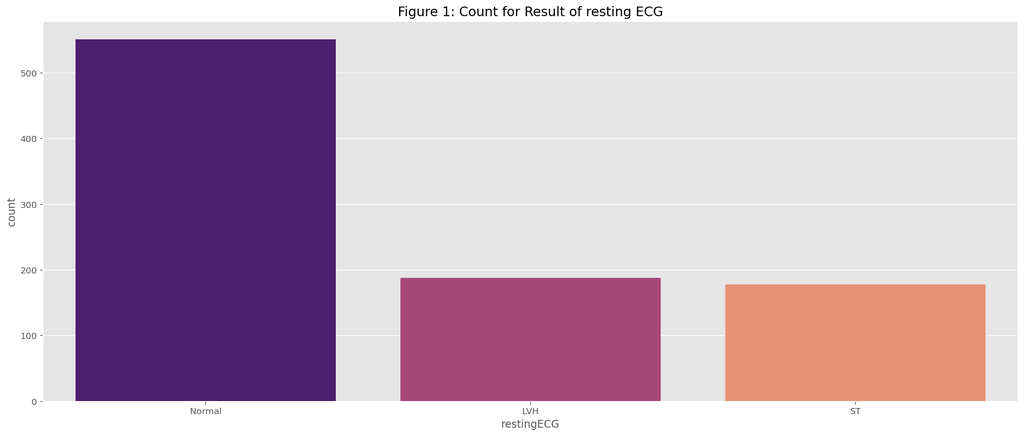

```python
plt.figure(figsize = (20,8))
fig = sns.countplot(x = 'restingECG', data = heart_df, palette = 'magma',
                    order = heart_df['restingECG'].value_counts().index)
fig = plt.title('Figure 1: Count for Result of resting ECG', fontsize = 15)
plt.show()
```

**Bar Chart of Sex**

Figure 2 shows the count of male and females that are in the dataset

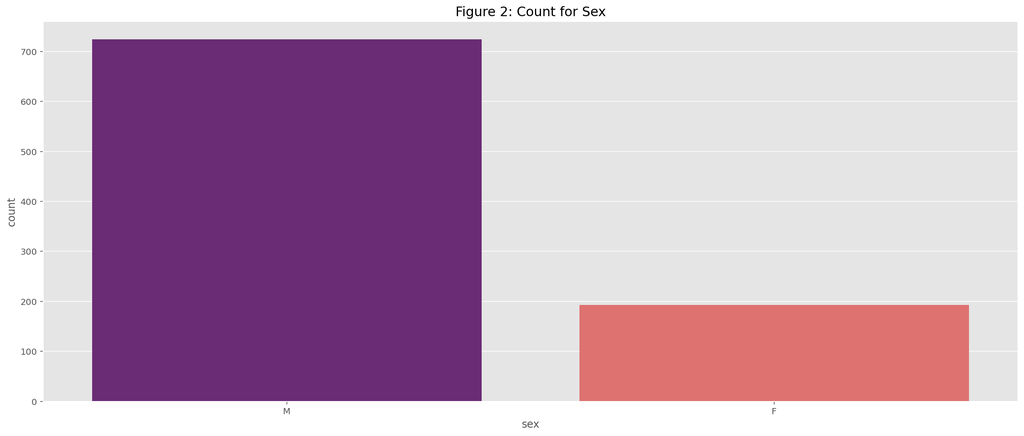

```python
plt.figure(figsize = (20,8))
fig = sns.countplot(x = 'sex', data = heart_df, palette = 'magma',
                    order = heart_df['sex'].value_counts().index)
fig = plt.title('Figure 2: Count for Sex', fontsize = 15)
plt.show()
```

**Boxplot of Resting BP**

Figure 3A shows that there are a few outliers that will need to be clamped in phase 2.

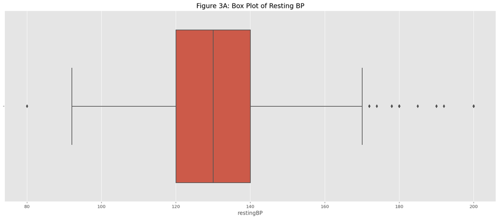

```python
plt.figure(figsize = (20,8))
sns.boxplot(heart_df['restingBP']).set_title('Figure 3A: Box Plot of Resting BP', fontsize = 15)
plt.show();
```

**Histogram of resting BP**

Figure 3B shows that the resting blood pressure is unimodal and mildly right skewed.

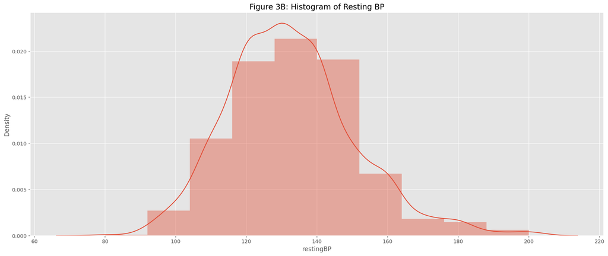

```python
plt.figure(figsize = (20,8))
sns.distplot(heart_df['restingBP'], kde=True, bins=10).set_title('Figure 3B: Histogram of Resting BP', fontsize = 15)
plt.show();
```

#### **Exploration 2**

**Boxplot of resting blood pressure grouped by resting ecg**

In Figure 4, the resting blood pressure for all 3 resting ECG categories are similar, with the upper quartile of ST and LVH being higher than normal.

[figure not shown]

```python
plt.figure(figsize = (20,12))
sns.boxplot(heart_df['restingECG'], heart_df['restingBP'])
plt.title('Figure 4: Boxplot of resting blood pressure grouped by resting ECG', fontsize = 15)
plt.xlabel('Resting Blood Pressure')
plt.ylabel('Resting ECG')
plt.show()
```

**Boxplot of resting blood pressure grouped by resting ECG and ST slope**

Figure 5 demonstrates a higher variance in blood pressure between ST slopes for those with ST variations and LVH. Noting the resting ECG category LVH and down ST slope showing significantly higher blood pressure ranges than the next highest.

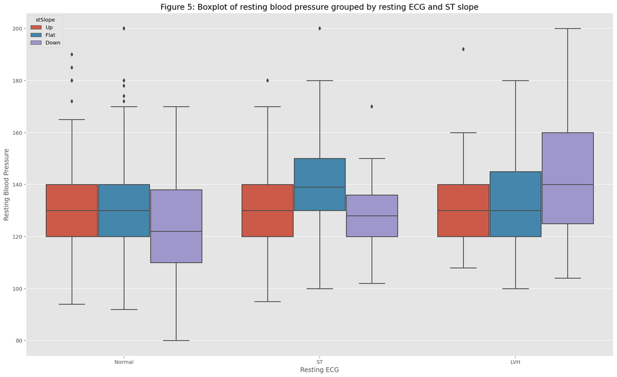

```python
plt.figure(figsize = (20,12))
sns.boxplot(heart_df['restingECG'], heart_df['restingBP'], hue=heart_df['stSlope'])
plt.title('Figure 5: Boxplot of resting blood pressure grouped by resting ECG and ST slope', fontsize = 15)
plt.xlabel('Resting ECG')
plt.ylabel('Resting Blood Pressure')
plt.show()
```

**Scatterplot of resting blood pressure against ST depression grouped by resting ECG category**

Figure 6 shows that there are very few instances of ST depression < 0 (indicating and ST elevation), and the majority falling between a depression of 0 to 2.

There is no clear pattern between resting ECG and either blood pressure and ST depression.

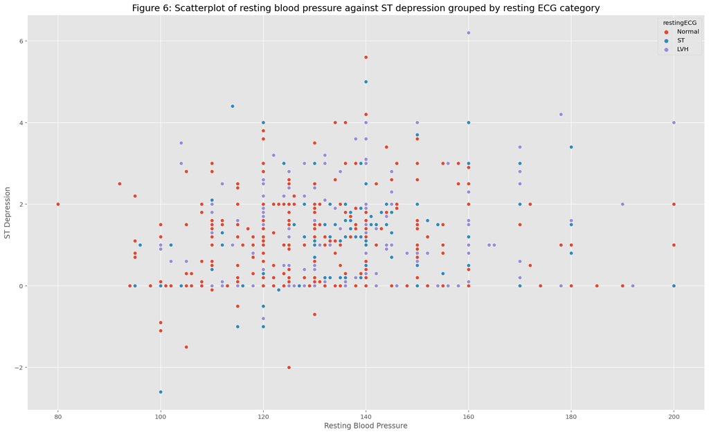

```python
plt.figure(figsize = (20,12))
sns.scatterplot(heart_df['restingBP'], heart_df['oldPeak'], hue=heart_df['restingECG'])
plt.title('Figure 6: Scatterplot of resting blood pressure against ST depression grouped by resting ECG category', fontsize = 15)
plt.xlabel('Resting Blood Pressure')
plt.ylabel('ST Depression')
plt.show()
```

#### **Exploration 3**

**Scatterplot of Resting Blood Pressure by Age**

From Figure 7, there is a noticable upward trend between people's Resting blood pressure and their age, meaning people tend to have higher resting blood pressure the older they are. However the severity of the trend should be noted as gradual.

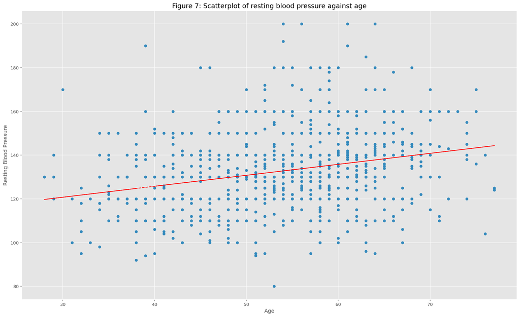

```python
plt.figure(figsize = (20,12))
sns.scatterplot(heart_df['age'], heart_df['restingBP'])
plt.title('Figure 7: Scatterplot of resting blood pressure against age', fontsize = 15)
plt.xlabel('Age')
plt.ylabel('Resting Blood Pressure')
x = heart_df['age']
y = heart_df['restingBP']
plt.scatter(x, y)

z = np.polyfit(x, y, 1)
p = np.poly1d(z)
plt.plot(x,p(x),"r--")
plt.show()
```

**Scatterplot of Cholesterol Level by Age**

Figure 8 below shows that there is no major relation beteen peoples age and cholesterol levels.

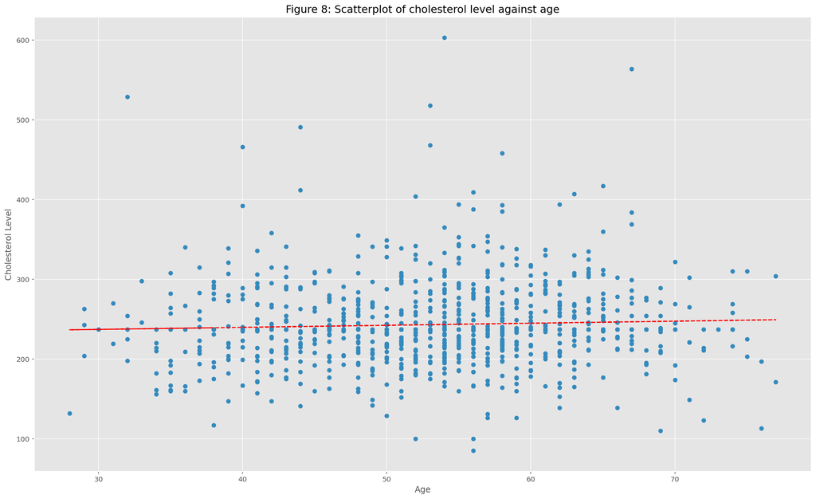

```python
plt.figure(figsize = (20,12))
sns.scatterplot(heart_df['age'], heart_df['cholesterol'])
plt.title('Figure 8: Scatterplot of cholesterol level against age', fontsize = 15)
plt.xlabel('Age')
plt.ylabel('Cholesterol Level')
x = heart_df['age']
y = heart_df['cholesterol']
plt.scatter(x, y)

z = np.polyfit(x, y, 1)
p = np.poly1d(z)
plt.plot(x,p(x),"r--")
plt.show()
```

# **Summary and Conclusions**

The prediction of high blood pressure based on health markers has been the subject of science and debate for some time now, as the ramifications for the correct prediction of this issue are significant and far-reaching. From the advancement of medical technologies by specifying key problem areas, to the simpler outcome of early detection, it is obvious that this data could have a massive impact on the lives of many.

As detailed above, for the first phase of this project we undertook to clean, preprocess and visualise the acquired dataset.

Initially we began this by standardising the naming conventions of all data features, along with examining the data for unique values and ranges to ensure data validity.

We noticed that the data has values which may need to undergo either clamping, scaling or encoding, however it is outside the scope of this report and will be performed in Phase 2.

We then proceeded to undertake visualisation to examine trends and patterns in the data through the use of various graph types.

From the graphs above, we can see that the resting blood pressure is unimodal and does have a few outliers that will need to be dealt with. Furthermore, it can be inferred that the older people get, the higher their resting blood pressure will be. This is the same for cholesterol levels, however the trend is not as severe as resting blood pressure and could almost be considered to have no relation at all.

There is also a potential positive correlation between abnormal resting ECG catergories and blood pressure, with ST slope being a possible indicator on the blood pressure range.

Further data analysis will be required in Phase 2 to better understand the key relationships between the various features.

# **References**

- fedesoriano. (September 2021). Heart Failure Prediction Dataset. Retrieved October 1, 2021 from https://www.kaggle.com/fedesoriano/heart-failure-prediction.